# Stat 451 Final Project: Loans Analysis

(Grace S, Grace D, Maya, Meg, Sowmya)

### Introduction

For our project, we analyzed a loans dataset that is publicly available from LendingClub.com, it can be found [here](https://www.kaggle.com/datasets/itssuru/loan-data).

Lenders earn money when people repay their loan but lose money when people do not. In order to predict whether a borrower would pay back their loan, with as much accuracy as possible, we pursued these questions:

```
1. Will a borrower repay their loan in full?
2. How can we classify whether a person will pay back their loan based on various features like FICO score, debt-to-income ratio, and interest rate?
```

We used a decision tree classifier, One Hot Encoding, and MinMaxScaler for feature engineering. Variable selection and regularization were conducted using Lasso regression, and a Random Forest Classifier was used to determine feature importance. Our conclusion indicated that our best models, with an accuracy of 84%, were no better than guessing, given that 84% of data samples were 0s.

### Data Source and Size

Our dataset, sourced from Kaggle, comprised ten thousand rows. We examined variables to distinguish between those who repaid their loans and those who did not. Our focus was on the variables interest rate, monthly installment, debt-to-income ratio, FICO score, unpaid amount, delinquency frequency, loan purpose, and log annual income.

### Data Exploration

Graphs comparing log annual income showed similar medians for both groups who did and did not repay. Most borrowers had zero delinquencies, with the repayment ratio roughly proportional across delinquency values.

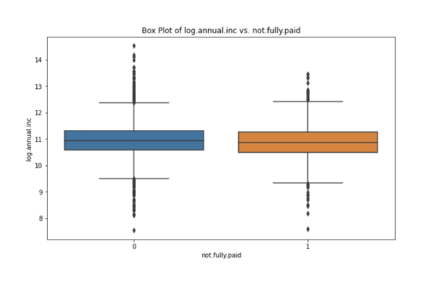

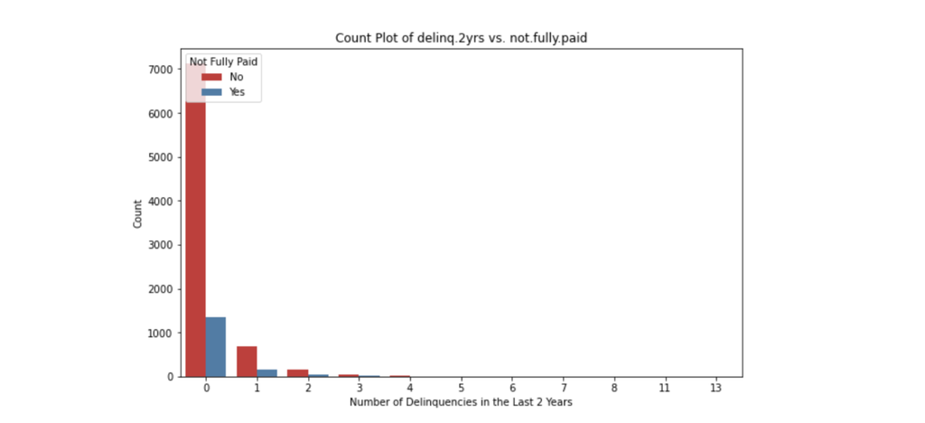

84% of loans were repaid.

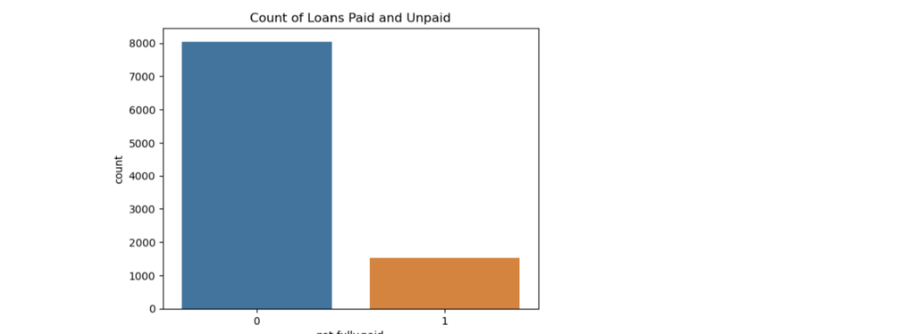

### Feature Engineering

We implemented one hot encoding for the purpose variable as well as min-max normalization on all variables. Attempts at feature selection with SelectKBest and f_classif were abandoned due to lower accuracy scores.

### Model Comparison

Our models included logistic regression, decision tree, and random forest classifier. A simple decision tree model showed overfitting, indicated by a perfect training score but lower validation accuracy.

Efforts to mitigate overfitting through hyperparameter tuning and adjusting the logistic regression decision threshold were successful but it was not better than just guessing. Eventually, we settled on three classifiers (log regression, decision tree, and random forest), each yielding an accuracy of approximately 0.84.

Our final models include a logistic regression model for C values of .01, 10,1000, a decision tree classifier with criterion entropy and max depth of 1 and 2 (max depth 1 pictured below), and a random forest classifier with max depth 11.

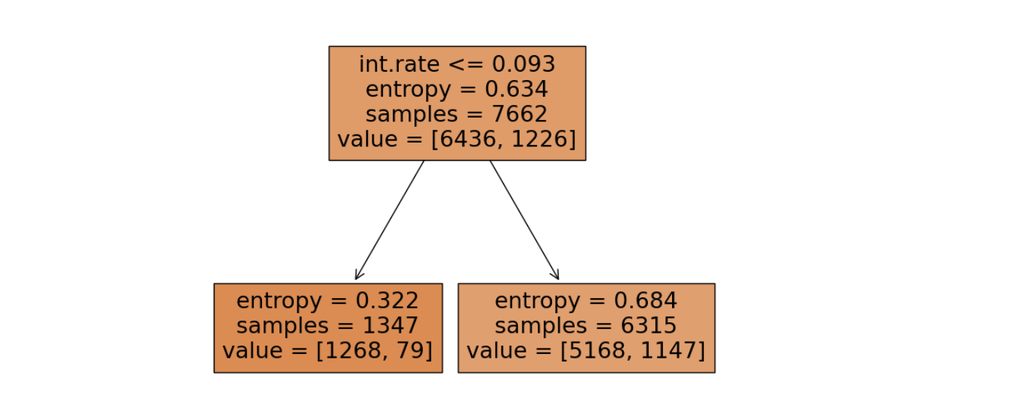

Our decision tree and logistic regression models predicted loan repayment, while the random forest model had one false positive. All models showed a precision of 0.84 and recall of 0. Lasso regression with C=1000 highlighted limited feature importance, with interest rate being a high-coefficient but low-impact predictor. A depth-1 decision tree based on interest rate consistently predicted 0, as seen in the graph above.

Random forest analysis using both impurity-based and permutation importance indicated that features were not highly impactful.

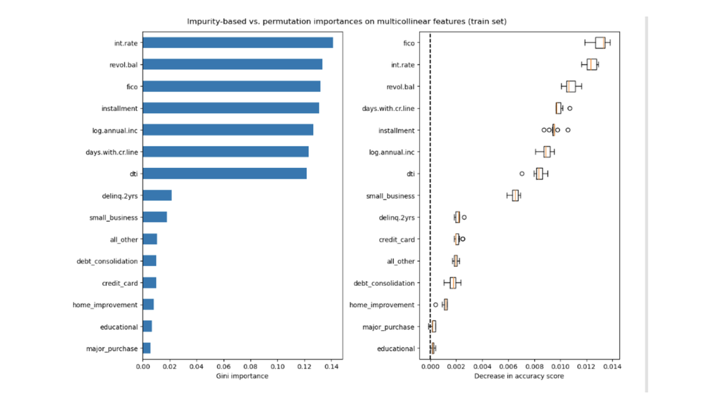

Addressing multicollinearity, hierarchical clustering on Spearman correlations reduced variables to 3 (as seen below), with minimal accuracy score impact. Ultimately, none of the features proved highly significant in predicting loan defaults.

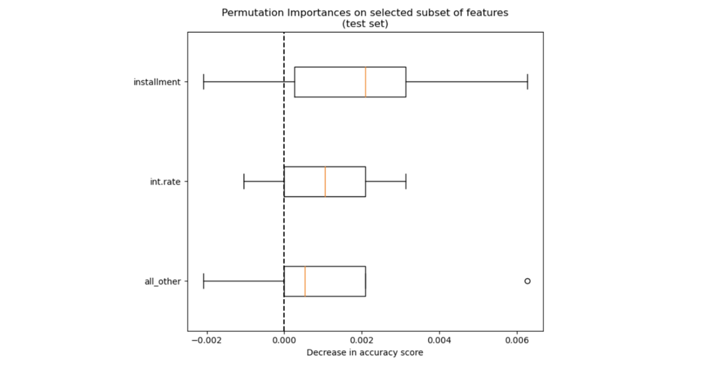

### Conclusion

In summary, our analysis didn't yield a conclusive model for predicting loan defaults or effectively classifying borrowers based on the chosen features. Predicting 0 remains the best approach until more informative variables are identified. Future considerations could include using the F1 score for model evaluation, especially given the dataset's imbalance and focus on the positive class.

### Contributions

| Member | Proposal | Coding | Presentation | Report |
| --- | --- | --- | --- | --- |
| Maya Barron | Filler | Filler | 1 | Filler |
| Sowmya Subramaniam | Filler | FIller | 1 | 1 |
| Meghna Krishna | Filler | Filler | 1 | Filler |
| Grace Sullivan | Filler | Filler | 1 | Filler |
| Grace Deis | Filler | Filler | 1 | 1 |